# Code for generating the data underlying the scRNA-seq-based figures in the SIFT-seq paper

Friederike Dündar

2/7/2022; updated 2022-02-09

```r
library(SingleCellExperiment); library(data.table);library(magrittr)
library(ggplot2); theme_set(theme_bw(base_size = 16) )
library(ggrepel); library(patchwork)
```

For each patient’s data set (0606T1, 21LT2, MR4050/MK_02), there’s a separate R package that contains the processed data as well as the code details of how that data was generated (check out the vignettes for that).

Here, we show how the figures shown in the SIFT-seq manuscript were generated although the final-final versions that made it into the paper were also done with GraphPadPrism for reasons of legibility.

```r
## load winners
data("cdrs0606T1", package = "Klebanoff0606T1")
data("cdrs21LT2", package = "Klebanoff21LT2")

## load SingleCellExperiment objects
sce.06 <- Klebanoff0606T1::load_0606T1shared()
Klebanoff0606T1::load_DE_results() #delist.both
de.06 <- delist.both

sce.21 <- Klebanoff21LT2::load_21LT2shared()
Klebanoff21LT2::load_DE_results() #delist.both
de.21 <- delist.both

rm(delist.both); invisible(gc())
```

## Fig 1

- 2. and (E): “tgrams” of IFNG logFC for 21LT2 and 0606T1, respectively
- 3. and (D): volcano plots and violin plots were done in GraphPad Prism, see the xlsx and txt files in the data directory

```r
t21  <- Klebanoff0606T1::prep_data4tgram(sce.21, which_clonotypes = unique(sce.21$id),
  DEresult_list = de.21, goi = "IFNG",
  additional_colData = c("antigen","freq_per_Sample", "freq_across_all","fit_for_test", "Patient"))

t06 <- Klebanoff0606T1::prep_data4tgram(sce.06, which_clonotypes = unique(sce.06$id),
  DEresult_list = de.06, goi = "IFNG",
  additional_colData = c("antigen","freq_per_Sample", "freq_across_all","fit_for_test", "Patient"))
```

```r
#' Extract T test results
#' @description returns the relevant values calculated
#' by R's \code{\link{t.test()}} in the form of a data.table.
#' @return data.table with logFC value (MUT/WT), standard error,
#' lower and upper bounds of the confidence interval.
extract.tres <- function(testres){
  logFC.t = testres$estimate[2] - testres$estimate[1] #levels: WT < MUT
  sde = testres$stderr
  ci.low = testres$conf.int[[2]]*-1 # needed b/c WT < MUT levels
  ci.up = testres$conf.int[[1]]*-1
  return(data.table(logFC.t = logFC.t, sde = sde, ci.low = ci.low, ci.up = ci.up))
}
```

```r
# 21LT2 ===================================
## calculate CI
test21res <- t21[
  fit_for_test == TRUE ,
  extract.tres(t.test(logcounts~antigen)),
  by = c("id", "gene_name")]

## summarize everything in one dt
t21.summ <- t21[, -c("cell", "cdr3s_aa","logcounts", "Sample","antigen", "freq_per_Sample"), with=FALSE] %>%
  unique %>% test21res[., on = "id"] %>% unique
t21.summ[ is.na(ci.low), ci.low:=0]
t21.summ[ is.na(ci.up), ci.up:=0]


# 0606T1 ====================================
## calculate CI etc.
test06res <- t06[
  fit_for_test == TRUE ,
  extract.tres(t.test(logcounts~antigen)),
  by = c("id", "gene_name")]

## summarize
t06.summ <- t06[, -c("cell", "cdr3s_aa","logcounts", "Sample","antigen", "freq_per_Sample"), with=FALSE] %>%
  unique %>% test06res[., on = "id"] %>% unique
t06.summ[ is.na(ci.low), ci.low:=0]
t06.summ[ is.na(ci.up), ci.up:=0]

t21.summ0 <- copy(t21.summ)
t21.summ0[, logFC := ifelse(logFC.t > 0, logFC.t, 0)]
t21.summ0[, logFC := ifelse(is.na(logFC.t), 0, logFC)]
t21.summ0[, ci.low0 := ifelse(logFC.t >0, ci.low, 0)]
t21.summ0[, ci.up0 := ifelse(logFC.t >0, ci.up, 0)]
setorder(t21.summ0, -freq_across_all)
t21.summ0$id.sort <- factor(t21.summ0$id, levels = t21.summ0$id, ordered = TRUE)

t06.summ0 <- copy(t06.summ)
t06.summ0[, logFC := ifelse(logFC.t > 0, logFC.t, 0)]
t06.summ0[, logFC := ifelse(is.na(logFC.t), 0, logFC)]
t06.summ0[, ci.low0 := ifelse(logFC.t >0, ci.low, 0)]
t06.summ0[, ci.up0 := ifelse(logFC.t >0, ci.up, 0)]
setorder(t06.summ0, -freq_across_all)
t06.summ0$id.sort <- factor(t06.summ0$id, levels = t06.summ0$id, ordered = TRUE)
```

```r
thresh <- 2
```

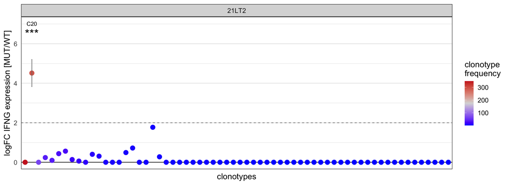

```r
ystar <- max(t21.summ0$logFC) + 2

ggplot(t21.summ0, aes(x = id.sort, y = logFC)) +
  geom_hline(yintercept = 0) +
  geom_hline(yintercept = thresh, linetype = "dashed", color = "grey50") +
  ## points -------------------------------
  geom_point(size = 4, aes(color = freq_across_all)) +
  scale_color_gradientn(
    name = "clonotype\nfrequency",
    colours = c("blue","grey85","firebrick3")) +
  ## error bars ---------------------------
  geom_errorbar(data = t21.summ0[logFC >= thresh],
    aes(ymin=ci.low0, ymax=ci.up0),
    width=.1, color="grey45") +
  facet_grid(. ~ Patient, scales="free_x", space = "free_x") +
  ## add asterisks -----------------------
  geom_text(inherit.aes = FALSE,
    aes(x = id.sort, y = ystar, label=star),
    colour="black", size=8)+
  geom_text(data = t21.summ0[star != ""],
    inherit.aes = FALSE,
    aes(x = id.sort, label = id, y = ystar+.5)) +
  ## grid appearance etc. ---------------
  theme(panel.grid.minor.x=element_blank(),
    panel.grid.major.x=element_blank(),
    axis.ticks = element_blank(),
    axis.text.x = element_blank()) +
  xlab("clonotypes") +
  ylab("logFC IFNG expression [MUT/WT]")
```

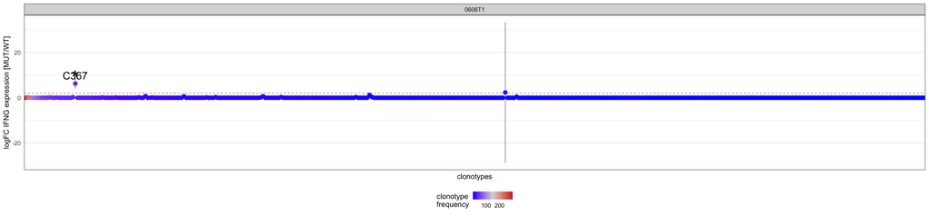

```r
ystar <- max(t06.summ0$logFC) + 2.5 ## DF

ggplot(t06.summ0, aes(x = id.sort, y = logFC)) + ## DF
  geom_hline(yintercept = 0) +
  geom_hline(yintercept = thresh, linetype = "dashed", color = "grey50") +
  ## points -------------------------------
  geom_point(size = 4, aes(color = freq_across_all)) +
  scale_color_gradientn(
    name = "clonotype\nfrequency",
    colours = c("blue","grey85","firebrick3")) +
  ## error bars ---------------------------
  geom_errorbar(data = t06.summ0[logFC >= thresh], ## DF
    aes(ymin=ci.low0, ymax=ci.up0),
    width=.1, color="grey45") +
  facet_grid(. ~ Patient, scales="free_x", space = "free_x") +
  ## add asterisks -----------------------
  geom_text(inherit.aes = FALSE,
    aes(x = id.sort, y = ystar, label=star),
    colour="black", size=15)+
  geom_text(data = t06.summ0[star != ""], ## DF
    inherit.aes = FALSE, size = 8,
    aes(x = id.sort, label = id, y = ystar+1)) +
  ## grid appearance etc. ---------------
  theme(panel.grid.minor.x=element_blank(),
    panel.grid.major.x=element_blank(),
    axis.ticks = element_blank(),
    axis.text.x = element_blank(),
    legend.position = "bottom") +
  xlab("clonotypes") +
  ylab("logFC IFNG expression [MUT/WT]")
```

## Ext Fig 3 and 4: boxplots of IFNg

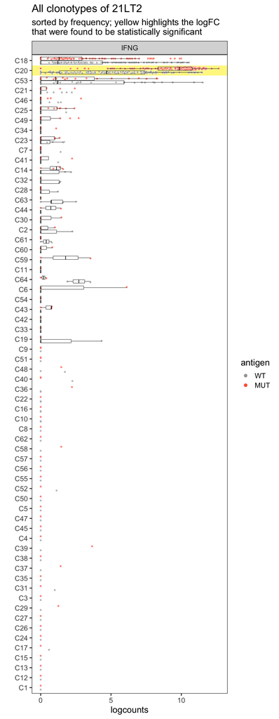

```r
t21  <- Klebanoff0606T1::prep_data4tgram(sce.21, which_clonotypes = unique(sce.21$id),
  DEresult_list = de.21, goi = "IFNG",
  additional_colData = c("antigen","freq_per_Sample", "freq_across_all","fit_for_test", "Patient"))
setorder(t21, freq_across_all)
t21$id <- factor(t21$id, levels = unique(t21$id), ordered = TRUE)

ggplot(t21, aes(x = id, y = logcounts))+
  geom_point(alpha = 0, aes(color = antigen)) +
  geom_tile(data=t21[star != ""],
      aes(x = id, y = 1, height = Inf, width = 1),
      alpha = 1, fill = "khaki1") +
  ggbeeswarm::geom_quasirandom(
   groupOnX = TRUE, size = 1.5, shape = 21, alpha =.7,
    dodge.width = .8, aes(fill = antigen), color = "white") +
  geom_boxplot(data=t21[freq_across_all > 3 ],
    outlier.alpha = 0,lwd=.25, fill = NA, aes(color = antigen)) +
  facet_grid(.~gene_name) + coord_flip() +
  xlab("") +
  theme(panel.grid = element_blank()) +
  scale_fill_manual(values = c("grey65","tomato1")) +
  scale_color_manual(values = c("black","black")) +
  ggtitle("All clonotypes of 21LT2", subtitle = "sorted by frequency; yellow highlights the logFC\nthat were found to be statistically significant") +
   guides(fill = guide_legend(override.aes = list(size = 3, alpha = 1) ),
      color = FALSE )
```

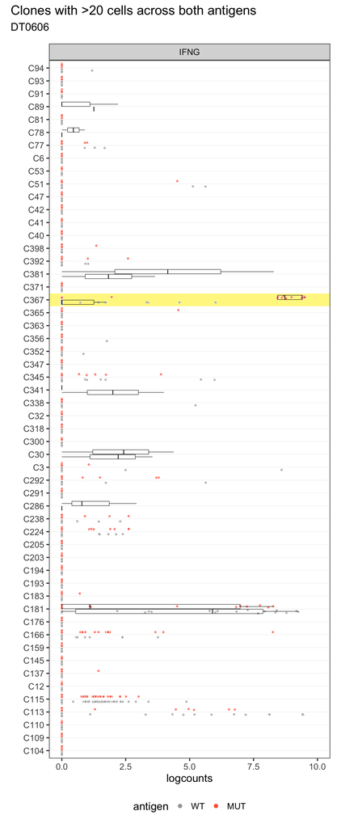

```r
t06  <- Klebanoff0606T1::prep_data4tgram(sce.06, which_clonotypes = unique(sce.06$id),
  DEresult_list = de.06, goi = "IFNG",
  additional_colData = c("antigen","freq_per_Sample", "freq_across_all","fit_for_test", "Patient"))
setorder(t06, freq_across_all)
t06$id <- factor(t06$id, levels = unique(t06$id), ordered = TRUE)

pl <- list()
ymax <- ceiling(max(t06$logcounts))

for(x in unique(t06$gene_name)){
  tmp <- t06[gene_name == x]
  bp <- tmp[, median(logcounts), by = c("antigen","id")] %>% .[V1 > 0] %>% .$id %>% as.character %>% unique
  P <- ggplot(tmp[freq_across_all > 20], aes(x = id, y = logcounts))
  if(nrow(tmp[star != ""])>0){
    P <- P + geom_point(alpha = 0, aes(color = antigen)) +
      geom_tile(data=tmp[star != ""],
        aes(x = id, y = 1, height = Inf, width = 1),
        alpha = 1, fill = "khaki1")
  }
  P <- P +  ggbeeswarm::geom_quasirandom(
    groupOnX = TRUE, size = 1.5, shape = 21, alpha =.7,
      dodge.width = .8, aes(fill = antigen), color = "white") +
    facet_grid(.~gene_name) + coord_flip(ylim = c(0,ymax)) +
    geom_boxplot(data=tmp[freq_across_all > 3 & as.character(id) %in% bp],
      outlier.alpha = 0,lwd=.25, fill = NA, aes(color = antigen)) +
    theme(
      legend.position = "bottom",
      panel.grid.minor = element_blank(),
      panel.grid.major.x = element_blank(),
      panel.grid.major.y = element_line(size = .2)) +
    xlab("") +
  scale_fill_manual(values =  c("grey65","tomato1")) +
  scale_color_manual(values = c("black","black")) +
    guides(fill = guide_legend(override.aes = list(size = 3, alpha = 1) ),
      color = FALSE )
  pl[[x]] <- P
}

pw06 <- pl[[1]]
pw06 + plot_annotation(title =  "Clones with >20 cells across both antigens", subtitle = "DT0606")
```

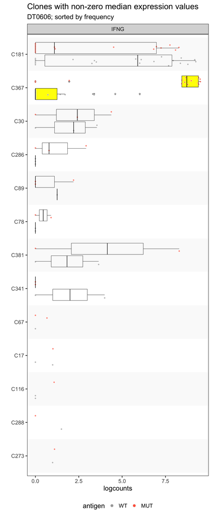

```r
# For DT0606 it probably makes more sense to show the ones with non-zero median expression values in at least one gene
medsT06 <- t06[, median(logcounts), by = c("antigen","id","gene_name")] %>%
  .[V1 > 0] %>% .$id  %>% as.character %>% unique

tmp <- t06[as.character(id) %in% medsT06]
setorder(tmp, freq_across_all)
tmp$id <- factor(tmp$id, levels = unique(tmp$id), ordered = TRUE)
odd_numbers <- levels(tmp$id)[seq(1, nlevels(tmp$id),2)]

ggplot(tmp, aes(x =id, y = logcounts))+
  geom_point(alpha = 0, aes(fill = antigen)) + # decoy points to set up the x axis
  ## grey background for alternating IDs
    geom_tile(
      data = tmp[as.character(id) %in% odd_numbers],
      aes(x = id, y = 1, height = Inf, width = 1),
      alpha = 1, fill = "grey98") +
    ## highlight sign. ones
    geom_boxplot(data=tmp[star != ""],
      outlier.alpha = 0.5,lwd=.25, fill = "yellow",
      aes(color = antigen)) +
  ## plot the actual values per sample
    ggbeeswarm::geom_quasirandom(
      groupOnX = TRUE, size = 1.5, shape = 21, alpha =.7,
      dodge.width = .8, aes(fill = antigen), color = "white") +
  facet_wrap(~gene_name) + coord_flip() +
  geom_boxplot(
    data=tmp[freq_across_all > 3],
    outlier.alpha = 0,lwd=.25, fill = NA, aes(color = antigen)) +
  ## remove grind lines etc.
  theme(
      legend.position = "bottom",
      panel.grid.minor = element_blank(),
      panel.grid.major.x = element_blank(),
      panel.grid.major.y = element_blank()) +
  xlab("") +
  scale_fill_manual(values =  c("grey65","tomato1")) +
  scale_color_manual(values = c("black","black")) +
  guides(
    fill = guide_legend(override.aes = list(size = 3, alpha = 1) ),
    color = FALSE ) +
  ggtitle("Clones with non-zero median expression values", subtitle = "DT0606; sorted by frequency")
```

## ExtDataFig 18: MR4050

- for volcano plots and boxplots (C-E), see `DEgenes_MR4050.xlsx` and `MR4050_C19_Winner_logcounts_CD3-4-8.txt` – these plots were, in fact, done with GraphPad Prism

```r
sce.mr <- KlebanoffMR4050::load_MR4050shared()
KlebanoffMR4050::load_DE_results()
de.mr <- delist.both

rm(delist.both); invisible(gc())

tmr  <- Klebanoff0606T1::prep_data4tgram(sce.mr, which_clonotypes = unique(sce.mr$id),
  DEresult_list = de.mr, goi = "IFNG",
  additional_colData = c("antigen","freq_per_Sample", "freq_across_all","fit_for_test", "Patient"))

# MR4050 ====================================
## calculate CI etc.
testMRres <- tmr[
  fit_for_test == TRUE ,
  extract.tres(t.test(logcounts~antigen)),
  by = c("id", "gene_name")]

## summarize
tMR.summ <- tmr[, -c("cell", "cdr3s_aa","logcounts", "Sample","antigen", "freq_per_Sample"), with=FALSE] %>%  unique %>% .[testMRres, on = "id"] %>% unique
tMR.summ[ is.na(ci.low), ci.low:=0]
tMR.summ[ is.na(ci.up), ci.up:=0]
```

- Error bar: SE

```r
tMR.summ0 <- copy(tMR.summ)

## if delta IFNG < 0, set to 0.
tMR.summ0[, logFC := ifelse(logFC.t > 0, logFC.t, 0)]
tMR.summ0[, ci.low0 := ifelse(logFC.t >0, ci.low, 0)]
tMR.summ0[, ci.up0 := ifelse(logFC.t >0, ci.up, 0)]

## sort by frequency
setorder(tMR.summ0, -freq_across_all)
tMR.summ0[, comb.ID := paste(id, Patient, sep = ".")]
tMR.summ0$id.sort <- factor(tMR.summ0$comb.ID, levels = tMR.summ0$comb.ID, ordered = TRUE)

tMR.summ0[is.na(FDR), FDR := 1]
tMR.summ0[, neg.log10.FDR := -1*log10(FDR)]
```

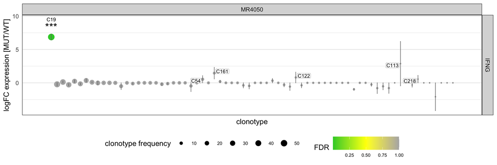

```r
ystar <- max(tMR.summ0$logFC.t) + 1.5
ggplot(tMR.summ0, aes(x = id.sort, y = logFC.t)) +
  geom_point(aes(size = freq_across_all, color = FDR)) +
  geom_errorbar(aes(ymin=logFC.t-sde, ymax=logFC.t+sde), width=.1, color="grey45") +
  facet_grid(gene_name ~ Patient, scales="free_x", space = "free_x") +
  ## add asterisks -----------------------
  geom_text(inherit.aes = FALSE,
    aes(x = id.sort, y = ystar, label=star),
    colour="black", size=8)+
  geom_text(data = tMR.summ0[star != ""],
    inherit.aes = FALSE,
    aes(x = id.sort, label = id, y = 9.5)) +
  ## grid appearance etc. ----------------
  theme(panel.grid.minor.x=element_blank(),
    panel.grid.major.x=element_blank(),
    axis.ticks = element_blank(),
    axis.text.x = element_blank(),
    legend.position = "bottom",
    legend.text = element_text( size = 10),
    legend.key.size = unit(2,"line")) +
  scale_color_gradientn( colours = rev(c("gray70","yellow","limegreen"))) +
  scale_size(name = "clonotype frequency") +
  xlab("clonotype") + ylab("logFC expression [MUT/WT]") +
  scale_x_discrete( expand = expansion(add = 5)) +
  ggrepel::geom_label_repel(
    data = tMR.summ0[logFC.t > 0.5 & id!="C19"],
    box.padding = 0.1, label.padding = 0.1, label.size = 0.1,
    aes(label = id))
```